# STA 3100 Programming with Data: Assignment 060

(90 points)

# Tinned Tuna

The file `tuna.csv` contains data on 106 different tins of tuna available for purchase from [Rainbow Tomatoes Garden](https://rainbowtomatoesgarden.com/). For each available item, the data include the name of the item, the price in dollars, the type of tuna and its Latin name, the country of origin, the brand, the size in grams and in “servings”, and a variety of other descriptors (packing liquid (oil or water), contains salt (yes or no), contains sugar (yes or no), smoked (yes or no), grilled (yes or no), organic (yes or no)).

## Note on Estimates, Confidence Intervals, and Tests of Hypotheses

In problems which require a point estimate, a confidence interval, and/or a test of hypotheses, you must express your results correctly and coherently **in words** in order to receive full credit.

# Exercises

1. (15 pts) Import `tuna.csv` into R. Give a table and a bar plot showing the number of tins of tuna of each type.

```r
tuna <- read.csv("C:/Users/camid/Documents/UF/SOPHOMORE YR/FALL2022/STA3100/tuna/tuna.csv")
tuna_tab <- table(tuna$Type)
tuna_tab
```

```
##
##  Albacore    Bigeye   Bluefin  Skipjack Yellowfin
##        43         5         9        22        27
```

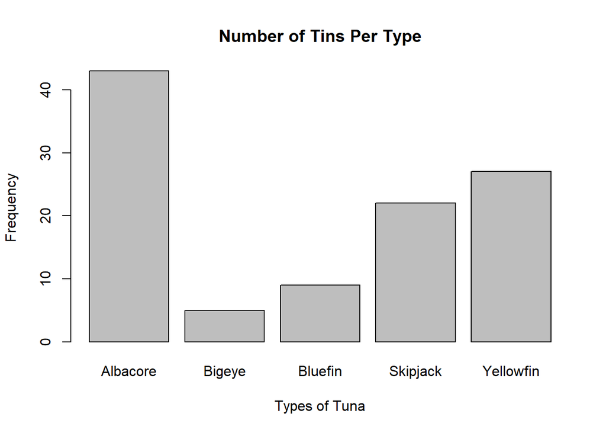

```r
barplot(tuna_tab, xlab = "Types of Tuna", ylab = "Frequency", main = "Number of Tins Per Type")
```

2. Shoppers usually expect to get a “better deal” if they purchase a larger quantity of any good, so it may be interesting to examine the relationship between per-gram price and tin size.

```
a. (7 pts) Fit a linear model regressing the per-gram price (`Price/Size`) on the size of the tin in grams (`Size`).  Save the fitted model as `lm_s` and print a summary of the fit.
```

```r
lm_s <- lm(Price/Size ~ Size, data = tuna)
summary(lm_s)
```

```
##
## Call:
## lm(formula = Price/Size ~ Size, data = tuna)
##
## Residuals:
##      Min       1Q   Median       3Q      Max
## -0.09034 -0.04825 -0.01954  0.02678  0.31501
##
## Coefficients:
##               Estimate Std. Error t value Pr(>|t|)
## (Intercept)  0.1996095  0.0222796   8.959 1.41e-14 ***
## Size        -0.0004975  0.0001471  -3.383  0.00101 **
## ---
## Signif. codes:  0 '***' 0.001 '**' 0.01 '*' 0.05 '.' 0.1 ' ' 1
##
## Residual standard error: 0.07084 on 104 degrees of freedom
## Multiple R-squared:  0.09913,    Adjusted R-squared:  0.09047
## F-statistic: 11.44 on 1 and 104 DF,  p-value: 0.001012
```

```
b. (10 pts) Using the model `lm_s` from part a, what would you estimate to be the change in mean per-gram price corresponding to a 100 gram increase in tin size? Express your result to the nearest penny (1/100 of a dollar) and give a 95% confidence interval.
```

```r
# a + bx --> a + b(x + 100) --> a + bx + 100b

pointInc100 <- round(100*-0.0004975, 2)

100*confint(lm_s)
```

```
##                  2.5 %      97.5 %
## (Intercept) 15.5428210 24.37908522
## Size        -0.0789113 -0.02058576
```

For 100 gram increase in tin size, the average per-gram price would decrease by an amount between 2 cents and 8 cents.

```
c. (10 pts) Using the model `lm_s` from part a, give a point estimate and a 95% confidence interval for the expected per-gram price of a tin weighing 120 grams. Express your results to the nearest penny (1/100 of a dollar).  (Hint: Use `predict()` with arguments `newdata = data.frame(Size = 120)` and `interval = "confidence"`. See the R help for `predict.lm()` for more information.)
```

```r
new <- data.frame(Size = 120)
predict(lm_s, new, interval = "confidence")
```

```
##         fit       lwr      upr
## 1 0.1399113 0.1245646 0.155258
```

For a tin of size 120 grams, the expected per-gram price is between 12 cents and 15 cents.

3. We might suspect that the average per-gram price also depends on the type of tuna.
   1. (7 pts) Extend the model from the previous problem by adding `Type` as a predictor. In this model, the effects of `Size` and `Type` on per-gram price should not depend on each other (i.e., this should be an “additive model” with “no interactions”). Save the fitted model as `lm_st` and print a summary of the fit.

```r
`Price/Size` <- tuna$Price/tuna$Size
lm_st <- lm(`Price/Size` ~ Size + Type, data = tuna)
summary(lm_st)
```

```
##
## Call:
## lm(formula = `Price/Size` ~ Size + Type, data = tuna)
##
## Residuals:
##      Min       1Q   Median       3Q      Max
## -0.13776 -0.03248 -0.00071  0.01759  0.18593
##
## Coefficients:
##                 Estimate Std. Error t value Pr(>|t|)
## (Intercept)    0.2093872  0.0194930  10.742  < 2e-16 ***
## Size          -0.0005217  0.0001210  -4.310 3.83e-05 ***
## TypeBigeye    -0.0454588  0.0272712  -1.667 0.098660 .
## TypeBluefin    0.1229403  0.0205623   5.979 3.49e-08 ***
## TypeSkipjack  -0.0519051  0.0147516  -3.519 0.000654 ***
## TypeYellowfin -0.0149561  0.0137854  -1.085 0.280564
## ---
## Signif. codes:  0 '***' 0.001 '**' 0.01 '*' 0.05 '.' 0.1 ' ' 1
##
## Residual standard error: 0.05608 on 100 degrees of freedom
## Multiple R-squared:  0.4571, Adjusted R-squared:  0.4299
## F-statistic: 16.84 on 5 and 100 DF,  p-value: 4.819e-12
```

```
b. (8 pts) Controlling for tin size, is there sufficient evidence to conclude that the per-gram price varies by tuna type?  Test at the $\alpha = 0.05$ level of significance.
```

```r
anova(lm_s, lm_st, test = "F")
```

```
## Analysis of Variance Table
##
## Model 1: Price/Size ~ Size
## Model 2: `Price/Size` ~ Size + Type
##   Res.Df     RSS Df Sum of Sq      F    Pr(>F)
## 1    104 0.52184
## 2    100 0.31450  4   0.20734 16.482 2.105e-10 ***
## ---
## Signif. codes:  0 '***' 0.001 '**' 0.01 '*' 0.05 '.' 0.1 ' ' 1
```

Controlling tin size, the p-value is 2.105e-10. This means that we are 95% confident in rejecting the null hypothesis. Therefore, we can state that there is enough evidence to assume that per-gram price varies by tuna type.

```
c. (10 pts) Using the model `lm_st` from part a, give a point estimate and a 95% confidence interval for the expected difference in per-gram price of a tin bluefin tuna versus a tin of albacore tuna of the same size. Express your results to the nearest penny (1/100 of a dollar).
```

```r
lm_st$coefficients["TypeBluefin"]
```

```
## TypeBluefin
##   0.1229403
```

```r
confint(lm_st, "TypeBluefin")
```

```
##                  2.5 %    97.5 %
## TypeBluefin 0.08214537 0.1637353
```

The point estimate for the expected difference in per-gram price of a tin bluefin tuna versus a tin of albacore tuna of the same size is 12 cents. We are 95% confidence that the expected difference per-gram between the type types is between 8 cents and 16 cents.

```
d. (15 pts) Provide a scatter plot of per-gram price (vertical axis) versus size in grams (horizontal axis). Use color to representing the different type of tuna and include the fitted lines implied by model `lm_st`. (Note: you should "jitter" the points to better reveal overlapping observations.  This can be done with `geom_point(position = "jitter")` or more succinctly with `geom_jitter()`.)
```

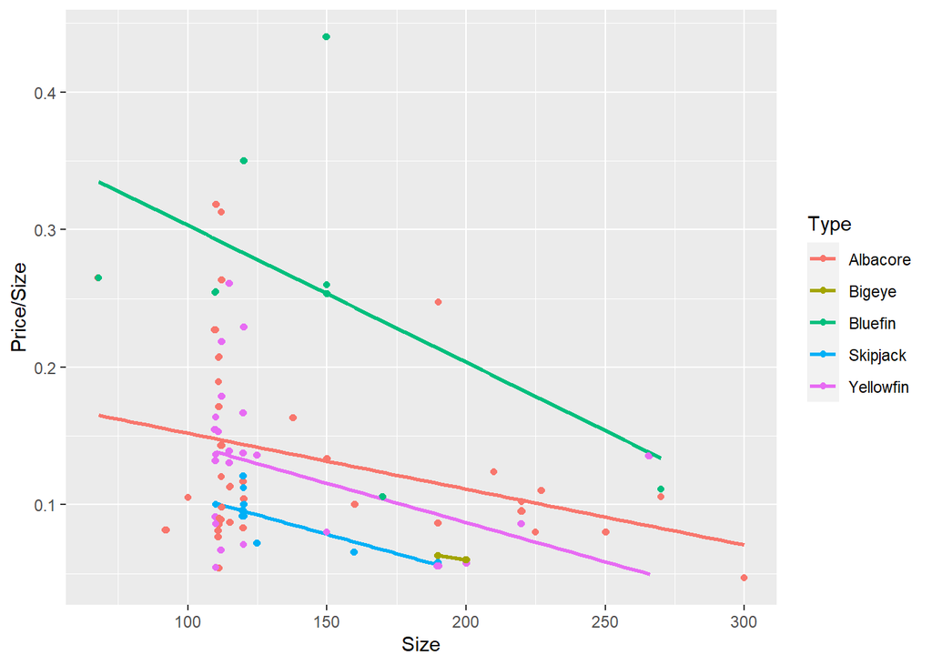

```r
library(ggplot2)

ggplot(lm_st, aes(x = Size, y = `Price/Size`, color = Type)) +
  geom_point()+
  geom_smooth(method = "lm", se = FALSE) +
  geom_point(position = "jitter")
```

4. (8 pts) Is there sufficient evidence to conclude that the effect of tin size on per-gram price depends on the type of tuna (or equivalently, that the effect of type of tuna depends on tin size)? Test at the $\alpha = 0.05$ level.

```r
lm_3 <- lm(`Price/Size` ~ Size * Type, data = tuna)
anova(lm_s, lm_st, lm_3)
```

```
## Analysis of Variance Table
##
## Model 1: Price/Size ~ Size
## Model 2: `Price/Size` ~ Size + Type
## Model 3: `Price/Size` ~ Size * Type
##   Res.Df     RSS Df Sum of Sq       F    Pr(>F)
## 1    104 0.52184
## 2    100 0.31450  4  0.207344 16.1926 3.626e-10 ***
## 3     96 0.30732  4  0.007178  0.5606    0.6918
## ---
## Signif. codes:  0 '***' 0.001 '**' 0.01 '*' 0.05 '.' 0.1 ' ' 1
```

The p value is 0.6918. This means that we cannot reject the null hypothesis, meaning we are 95% sure that we cannot assume that the effect of tin size on per-gram price depends on the type of tuna.